# Machine Learning: Naive Bayes

**Please refer to** [Jupyter NBExtension Readme page](https://jupyter-contrib-nbextensions.readthedocs.io/en/latest/nbextensions/toc2/README.html) **to display**  
**the table of contents in floating window and expand the body of the contents.**

# Question 1 - Naive Bayes

Based on the US Census Income Dataset that we have been using in this course. The annual_income target variable is binary, which is either high_income or low_income. As usual, high income will be the positive class for this problem.

For this question, we would use different variations of the Naive Bayes (NB) classifier for predicting the annual_income target feature and present our results as Pandas data frames.

## Part A - Data Preparation

### Task 1

Transform the 2 numerical features (age and education_years) into 2 (nominal) categorical features. Specifically, use **equal-width binning** with the following 3 bins for each numerical feature: `low`, `mid`, and `high`. Once this is done, all the 5 descriptive features in our dataset will be categorical. Dataset's name after Task 1 will be named as **df_all_cat**.

- Step 1: Import all necessary packages: numpy, pandas and tabulate, and set the appropriate display options

```python
import pandas as pd
import numpy as np
pd.set_option('display.max_columns', None)
import warnings
warnings.filterwarnings("ignore")
import matplotlib.pyplot as plt
import seaborn as sns
from sklearn.preprocessing import PowerTransformer
```

- Step 2: Read in the `A3_Q1_train.csv` file to the dataframe `df`, drop the column `row_id` as it is an index

```python
df = pd.read_csv("A3_Q1_train.csv")
df=df.drop(columns='row_id')
```

```python
df.head()
```

|  | age | education_years | workclass | marital_status | occupation | annual_income |
| --- | --- | --- | --- | --- | --- | --- |
| 0 | 48 | 14 | Local-gov | Divorced | Prof-specialty | high_income |
| 1 | 23 | 13 | Local-gov | Never-married | Prof-specialty | low_income |
| 2 | 45 | 13 | Local-gov | Never-married | Prof-specialty | low_income |
| 3 | 51 | 13 | Federal-gov | Married-civ-spouse | Exec-managerial | low_income |
| 4 | 51 | 14 | Local-gov | Married-civ-spouse | Prof-specialty | high_income |

- Step 3: Copy all the information in `df` to a new dataframe `df_all_cat`, drop the `age` and `education_years` column.

```python
df_all_cat = df.copy()
df_all_cat=df_all_cat.drop(columns=['age', 'education_years'])
```

- Step 4: Use the **cut** function to bin `df`'s `age` and `education_years` into equal-width. Assign these binned values to `df_all_cat` as `age` and `education_years` respectively. Re-arrange the column order in `df_all_cat`, so that it follows the same order as the read-in `df`.

```python
df_all_cat['age']=pd.cut(df['age'],3, labels=["low", "mid", "high"])
df_all_cat['education_years']=pd.cut(df['education_years'],3, labels=["low", "mid", "high"])
neworder = ['age','education_years','workclass', 'marital_status', 'occupation', 'annual_income']
df_all_cat=df_all_cat.reindex(columns=neworder)
```

- Step 5: Display the value_counts of each column in `df_all_cat`

```python
for col in df_all_cat.columns.to_list():
    print(col + ':')
    print(df_all_cat[col].value_counts())
    print('********')
```

```
age:
mid     230
low     140
high    130
Name: age, dtype: int64
********
education_years:
high    304
mid     193
low       3
Name: education_years, dtype: int64
********
workclass:
Local-gov      225
State-gov      148
Federal-gov    127
Name: workclass, dtype: int64
********
marital_status:
Married-civ-spouse    230
Never-married         155
Divorced              115
Name: marital_status, dtype: int64
********
occupation:
Prof-specialty     224
Adm-clerical       159
Exec-managerial    117
Name: occupation, dtype: int64
********
annual_income:
low_income     320
high_income    180
Name: annual_income, dtype: int64
********
```

### Task 2

Perform one-hot-encoding (OHE) on the dataset (after the equal-width binning above). Dataset will be named as `df_all_cat_ohe` after task 2.

- Step 1: Copy all the information in `df_all_cat` to a new dataframe `df_all_cat_ohe`, drop the `annual_income` column.

```python
df_all_cat_ohe = df_all_cat.copy()
df_all_cat_ohe=df_all_cat_ohe.drop(columns=['annual_income'])
```

- Step 2: Perform one-hot-encoding to all the columns in `df_all_cat_ohe`, such that one-hot-encoding is done on all the descriptive feature.

```python
for col in df_all_cat_ohe.columns.to_list():
    n = len(df_all_cat_ohe[col].unique())
    if (n == 2):
        df_all_cat_ohe[col] = pd.get_dummies(df_all_cat_ohe[col], drop_first=True)
df_all_cat_ohe = pd.get_dummies(df_all_cat_ohe)
```

- Step 3: The `labelEncoder` or `get_dummies` function would encode the labels in alphabetical order, which will turn `high_income` = 0 and `low_income`=1. As `high_income` is positive class in `annual_income`, we would like to encode `high_income` as 1 and `low_income` as 0. To do so, we can call the `replace` function on `df_all_cat['annual_income']` and assign the result to a new column `annual_income` for `df_all_cat_ohe`.

```python
df_all_cat_ohe['annual_income'] = pd.Series(df_all_cat['annual_income']).replace({'low_income': 0, 'high_income': 1}).values
```

- Step 4: Display the shape and the first five rows of `df_all_cat_ohe`

```python
print(df_all_cat_ohe.shape)
df_all_cat_ohe.head()
```

```
(500, 16)
```

|  | age_low | age_mid | age_high | education_years_low | education_years_mid | education_years_high | workclass_Federal-gov | workclass_Local-gov | workclass_State-gov | marital_status_Divorced | marital_status_Married-civ-spouse | marital_status_Never-married | occupation_Adm-clerical | occupation_Exec-managerial | occupation_Prof-specialty | annual_income |
| --- | --- | --- | --- | --- | --- | --- | --- | --- | --- | --- | --- | --- | --- | --- | --- | --- |
| 0 | 0 | 0 | 1 | 0 | 0 | 1 | 0 | 1 | 0 | 1 | 0 | 0 | 0 | 0 | 1 | 1 |
| 1 | 1 | 0 | 0 | 0 | 0 | 1 | 0 | 1 | 0 | 0 | 0 | 1 | 0 | 0 | 1 | 0 |
| 2 | 0 | 1 | 0 | 0 | 0 | 1 | 0 | 1 | 0 | 0 | 0 | 1 | 0 | 0 | 1 | 0 |
| 3 | 0 | 0 | 1 | 0 | 0 | 1 | 1 | 0 | 0 | 0 | 1 | 0 | 0 | 1 | 0 | 0 |
| 4 | 0 | 0 | 1 | 0 | 0 | 1 | 0 | 1 | 0 | 0 | 1 | 0 | 0 | 0 | 1 | 1 |

## Part B - Bernoulli NB

- Step 1: Drop the target feature `annual income` in `df_all_cat_ohe` such that it will only contain descriptive features, turn `df_all_cat_ohe` into a numpy array and name it `Data`. Also turn the target feature `df_all_cat_ohe["annual_income"]` into a numpy array and name it `target`.

```python
Data = df_all_cat_ohe.drop(columns="annual_income").values
target = df_all_cat_ohe["annual_income"].values
```

```python
print(type(Data))
print(type(target))
```

```
<class 'numpy.ndarray'>
<class 'numpy.ndarray'>
```

- Step 2: Check the unique count in `target`. Count for 1 should equal to value count of high_income in `df_all_cat['annual income']`, count for 0 should equal to value count of low_income in `df_all_cat['annual income']`

```python
np.unique(target, return_counts = True)
```

```
(array([0, 1], dtype=int64), array([320, 180], dtype=int64))
```

- Step 3: Train ther Bernoulli NB model with default parameter, using the entire set of `Data` and `target`. Compute the accuracy on the whole set of train data.

```python
from sklearn.naive_bayes import BernoulliNB
```

```python
bnb_classifier = BernoulliNB()
bnb_classifier.fit(Data, target)
bnb_classifier.score(Data, target)
```

```
0.83
```

- Step 3: Define a dataframe `df_summary` to display the accuracy scores of different variation of NB classifiers :
  - 1st column will contain the method of the classifier
  - 2nd column will contain the accuracy score of that classifier.

We would use `df_summary` extensively in part F

```python
df_summary = pd.DataFrame(columns=['method', 'accuracy'])
```

- Step 4: Add the Bernoulli NB result into the first row of `df_summary`

```python
df_summary.loc[len(df_summary)] = ['Bernoulli NB', bnb_classifier.score(Data, target)]
```

## Part C - Gaussian NB

- Step 1: Train the Gaussian NB model with default parameter, using the entire set of `Data` (all features will be binary) and `target`. Compute the accuracy on the whole set of train data.

```python
from sklearn.naive_bayes import GaussianNB
```

```python
gnb_classifier = GaussianNB()
gnb_classifier.fit(Data, target)
gnb_classifier.score(Data, target)
```

```
0.728
```

- Step 2: Add the Gaussian NB result into the second row of `df_summary`

```python
df_summary.loc[len(df_summary)] = ['Gaussian NB', gnb_classifier.score(Data, target)]
```

## Part D - Performance Tuning

### Task 1 - Tuning

- Step 1: Define a dataframe `bnb_result`:
  - 1st column will contain the parameter value `alpha` of the `BernoulliNB` classifier
  - 2nd column will contain the accuracy score obtained from fitting `Data` into `BernoulliNB` classifier with the respective `alpha` parameter in 1st column

```python
 bnb_result= pd.DataFrame(columns=['alpha', 'accuracy_score'])
```

- Step 2: Use a for loop to train the `BernoulliNB` classifier ranging from 1 to 500, store the `alpha` value and `accuracy` score into the dataframe `bnb_result`

```python
for alpha_value in np.arange(1,500):
#    print(alpha_value)
    bnb_classifier = BernoulliNB(alpha=alpha_value)
    Data_transformed = PowerTransformer().fit_transform(Data)
    bnb_classifier.fit(Data_transformed, target)
    accuracy=bnb_classifier.score(Data_transformed, target).round(3)
    bnb_result.loc[len(bnb_result)] = [alpha_value, accuracy]
```

- Step 3: Define a dataframe `gnb_result`:
  - 1st column will contain the parameter value `var_smoothing` of the `GaussianNB` classifier
  - 2nd column will contain the accuracy score obtained from fitting `Data` into `GaussianNB` classifier with the respective `var_smoothing` parameter in 1st column

```python
gnb_result = pd.DataFrame(columns=['var_smoothing', 'accuracy_score'])
```

```python
for var_smoothing_value in np.logspace(1,-9, num=100):
    gnb_classifier = GaussianNB(var_smoothing=var_smoothing_value)
    Data_transformed = PowerTransformer().fit_transform(Data)
    gnb_classifier.fit(Data_transformed, target)
    accuracy=gnb_classifier.score(Data_transformed, target).round(3)
    gnb_result.loc[len(gnb_result)] = [var_smoothing_value, accuracy]
```

### Task 2 - Plotting

- Step 1: Plot the Bernoulli NB tuning results

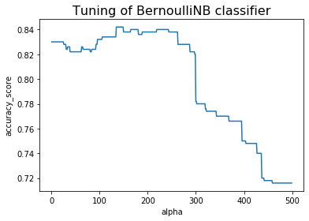

```python
sns.lineplot(x="alpha", y="accuracy_score", data=bnb_result)
plt.title('Tuning of BernoulliNB classifier', fontsize = 16)
```

- Step 2: List the top 5 alpha with the highest accuracy score

```python
bnb_result_desc_order = bnb_result.sort_values(by=["accuracy_score"], ascending = False).reset_index(drop=True)
```

```python
bnb_result_desc_order.head(5)
```

|  | alpha | accuracy_score |
| --- | --- | --- |
| 0 | 135.0 | 0.842 |
| 1 | 144.0 | 0.842 |
| 2 | 136.0 | 0.842 |
| 3 | 137.0 | 0.842 |
| 4 | 138.0 | 0.842 |

- Step 3: Add the best tuned Bernoulli NB result into the third row of `df_summary`

```python
df_summary.loc[len(df_summary)] = ['Tuned Bernoulli NB', bnb_result_desc_order["accuracy_score"][0]]
```

- Step 4: Plot the Gaussian NB tuning results

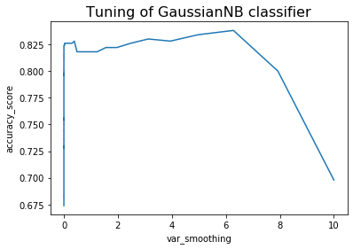

```python
sns.lineplot(x="var_smoothing", y="accuracy_score", data=gnb_result)
plt.title('Tuning of GaussianNB classifier', fontsize = 16)
```

- Step 5: List the top 5 alpha with the highest accuracy score

```python
gnb_result_desc_order = gnb_result.sort_values(by=["accuracy_score"], ascending = False).reset_index(drop=True)
gnb_result_desc_order.head(5)
```

|  | var_smoothing | accuracy_score |
| --- | --- | --- |
| 0 | 6.280291 | 0.838 |
| 1 | 4.977024 | 0.834 |
| 2 | 3.125716 | 0.830 |
| 3 | 3.944206 | 0.828 |
| 4 | 0.385353 | 0.828 |

```python
gnb_result_desc_order["accuracy_score"]
```

```
0     0.838
1     0.834
2     0.830
3     0.828
4     0.828
      ...
95    0.682
96    0.680
97    0.678
98    0.676
99    0.674
Name: accuracy_score, Length: 100, dtype: float64
```

- Step 6: Add the best tuned Gaussian NB result into the fourth row of `df_summary`

```python
df_summary.loc[len(df_summary)] = ['Tuned Gaussian NB', gnb_result_desc_order["accuracy_score"][0]]
```

## Part E - Hybrid NB

In real world, we would usually work with datasets with a mix of categorical and numerical features. We have covered two NB variants so far:

- Bernoulli NB that assumes all descriptive features are binary, and
- Gaussian NB that assumes all descriptive features are numerical and they follow a Gaussian probability distribution.

The purpose of this part is to implement a Hybrid NB Classifier on the "A3_Q1_train.csv" dataset that uses Bernoulli NB (with default parameters) for categorical descriptive features and Gaussian NB (with default parameters) for the numerical descriptive features. You will specifically train your Hybrid NB model using the train data and compute its accuracy on again train data.

### Task 1 - Split Dataset

Step 1: Construct the dataframe `df_numeric`, first 2 columns, `age` and `education_years` would be continuous (copy from dataframe `df`), while the rest of the categorical features would be resided in the dataframe `df_cat`.

```python
df.dtypes
```

```
age                 int64
education_years     int64
workclass          object
marital_status     object
occupation         object
annual_income      object
dtype: object
```

```python
df_numeric = df[['age', 'education_years']].copy()
```

```python
df_cat = df.select_dtypes(include='object').drop(columns='annual_income')
```

```python
df_numeric.dtypes
```

```
age                int64
education_years    int64
dtype: object
```

```python
df_cat.dtypes
```

```
workclass         object
marital_status    object
occupation        object
dtype: object
```

### Task 2 - Transformation Check (Numeric Portion Only)

Before we train `df_numeric` with Gaussian NB. Our numeric data may not have a Gaussian (Normal) distribution and Gaussian NB classifier would have better performance if the data follow Gaussian distribution. Test and see if we need to apply power or Boxcox transformation in this dataset before training the data.

- Step 1: Plot the distribution for **Age**, compare with and without transformation

```python
from scipy import stats

df_age = pd.DataFrame()
df_age['original']=df_numeric['age']

df_numeric_transformed =  PowerTransformer().fit_transform(df_numeric)
df_age['power']=df_numeric_transformed[:,0]
tdata = stats.boxcox(df_numeric['age'])
df_age['boxcox']=tdata[0]
df_age.head()
```

|  | original | power | boxcox |
| --- | --- | --- | --- |
| 0 | 48 | 0.844505 | 58.088388 |
| 1 | 23 | -1.561055 | 25.905422 |
| 2 | 45 | 0.549372 | 54.146006 |
| 3 | 51 | 1.141063 | 62.048351 |
| 4 | 51 | 1.141063 | 62.048351 |

```python
df_age_long=df_age.melt(var_name=["data"])
```

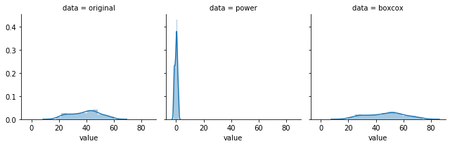

```python
df_age_long=df_age.melt(var_name=["data"])
g = sns.FacetGrid(df_age_long, col="data")
g.map(sns.distplot, "value")
```

Side-by-side comparison is not clear, let's plot the distribution separately.

**Original**

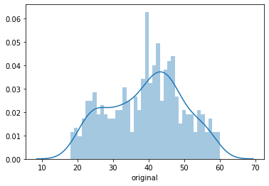

```python
sns.distplot(df_age['original'],
             kde=True,
             bins=40);
```

**Power Transformed**

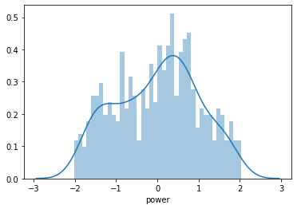

```python
sns.distplot(df_age['power'],
             kde=True,
             bins=40);
```

**Box-Cox Transformed**

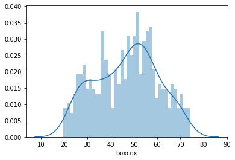

```python
sns.distplot(df_age['boxcox'],
             kde=True,
             bins=40);
```

- Step 2: Plot the distribution for **Education years**, compare with and without transformation

```python
df_ed = pd.DataFrame()
df_ed['original']=df_numeric['education_years']
df_ed['power']=df_numeric_transformed[:,1]
tdata = stats.boxcox(df_numeric['education_years'])
df_ed['boxcox']=tdata[0]
df_ed.head()
```

|  | original | power | boxcox |
| --- | --- | --- | --- |
| 0 | 14 | 0.944526 | 73.582644 |
| 1 | 13 | 0.407072 | 63.999017 |
| 2 | 13 | 0.407072 | 63.999017 |
| 3 | 13 | 0.407072 | 63.999017 |
| 4 | 14 | 0.944526 | 73.582644 |

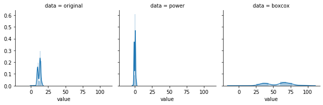

```python
df_ed_long=df_ed.melt(var_name=["data"])
g = sns.FacetGrid(df_ed_long, col="data")
g.map(sns.distplot, "value")
```

Side-by-side comparison is not clear, let's plot the distribution separately.

**Original**

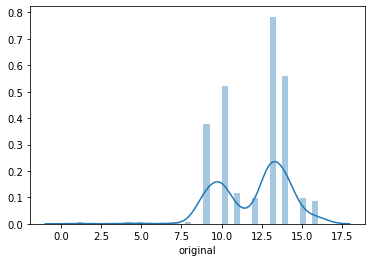

```python
sns.distplot(df_ed['original'],
             kde=True,
             bins=40);
```

**Power Transformed**

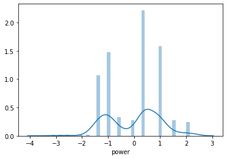

```python
sns.distplot(df_ed['power'],
             kde=True,
             bins=40);
```

**Box-Cox Transformed**

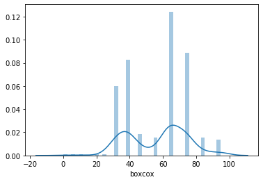

```python
sns.distplot(df_ed['boxcox'],
             kde=True,
             bins=40);
```

- Step 3: Draw conclusion

Visual comparison, there is not much change for the distributions (for both **Age** and **Education years**) after being transformed. We would just use the original numeric dataset for training.

### Task 3 - Train and combine the outcomes

- Step 1: Train the numeric portion using Gaussian NB

```python
clf_GaussianNB = GaussianNB()
clf_GaussianNB.fit(df_numeric, target)

t_pred_GaussianNB = clf_GaussianNB.predict(df_numeric)
```

- Step 2: Train the categorical portion using Bernoulli NB

```python
data_cat_ohe = pd.get_dummies(df_cat)

clf_BernoulliNB = BernoulliNB()
clf_BernoulliNB.fit(data_cat_ohe, target)

t_pred_BernoulliNB = clf_BernoulliNB.predict(data_cat_ohe)
```

- Step 3: Obtain the probability estimate of the label classes for each classifier and combine the outcomes

```python
prob_BernoulliNB = clf_BernoulliNB.predict_proba(data_cat_ohe)
prob_GaussianNB = clf_GaussianNB.predict_proba(df_numeric)

results_combined = pd.DataFrame({'BernoulliNB_0':prob_BernoulliNB[:,0],
                                 'BernoulliNB_1':prob_BernoulliNB[:,1],
                                 'GaussianNB_0':prob_GaussianNB[:,0],
                                 'GaussianNB_1':prob_GaussianNB[:,1]})
```

- Step 4: Calculate prior of each label classes based on the occurrence in the dataset

```python
count_0 = np.count_nonzero(target == 0)
count_1 = np.count_nonzero(target == 1)
prior_0 = count_0 / (count_0+count_1)
prior_1 = count_1 / (count_0+count_1)
print(prior_0)
print(prior_1)
```

```
0.64
0.36
```

### Task 4 - Class and Score the Hybrid model

- Step 1: Calculate Likelihood: Since Posterior ∝ Prior * Likelihood ==> Likelihood = Posterior / Prior

```python
results_combined['HybridNB_0'] = results_combined['BernoulliNB_0']*results_combined['GaussianNB_0'] / prior_0
results_combined['HybridNB_1'] = results_combined['BernoulliNB_1']*results_combined['GaussianNB_1'] / prior_1
```

- Step 2 : Class if higher final probability is assigned from the prediction

```python
results_combined['Target_Hybrid'] = np.where(results_combined['HybridNB_0'] > results_combined['HybridNB_1'], 0, 1)

results_combined.head()
```

|  | BernoulliNB_0 | BernoulliNB_1 | GaussianNB_0 | GaussianNB_1 | HybridNB_0 | HybridNB_1 | Target_Hybrid |
| --- | --- | --- | --- | --- | --- | --- | --- |
| 0 | 0.972532 | 0.027468 | 0.280403 | 0.719597 | 0.426096 | 0.054905 | 0 |
| 1 | 0.988022 | 0.011978 | 0.940321 | 0.059679 | 1.451652 | 0.001986 | 0 |
| 2 | 0.988022 | 0.011978 | 0.387028 | 0.612972 | 0.597487 | 0.020396 | 0 |
| 3 | 0.041132 | 0.958868 | 0.337925 | 0.662075 | 0.021718 | 1.763451 | 1 |
| 4 | 0.184389 | 0.815611 | 0.266350 | 0.733650 | 0.076737 | 1.662147 | 1 |

- Step 3: Compute the accuracy on the whole set of train data.

```python
from sklearn import metrics
max_score_HybridNB_Final = metrics.accuracy_score(target, results_combined['Target_Hybrid'].values)
print(f'{max_score_HybridNB_Final:.3f}')
```

```
0.842
```

- Step 4: Add the Hybrid NB result into the fifth row of `df_summary`

```python
df_summary.loc[len(df_summary)] = ['Hybrid NB', max_score_HybridNB_Final]
```

## Part F - Wrapping up

- display `df_summary`

```python
df_summary
```

|  | method | accuracy |
| --- | --- | --- |
| 0 | Bernoulli NB | 0.830 |
| 1 | Gaussian NB | 0.728 |
| 2 | Tuned Bernoulli NB | 0.842 |
| 3 | Tuned Gaussian NB | 0.838 |
| 4 | Hybrid NB | 0.842 |

From `df_summary`, it shows that hyper-parameter tuning would really improve the performance for both Bernoulli and Gaussian NB. The accuracy of hybrid NB model is the better than both untuned Bernoulli NB and untuned Gaussian NB for this particular dataset.